# EXERCISES

NU Pathology LearnR! Fall 2020 Session 2

## DATA VISUALIZATION

### EXTEND: Using built-in data and quick plots

You wouldn’t fully experience learning plotting with `ggplot2` if you didn’t work with the diamonds data set that is built in to `ggplot2`. This data set contains the prices and other attributes of almost 54,000 diamonds. Since the data set is available once you load the `ggplot2` package, you can use `diamonds` as you would any data object and R knows what you mean, as shown in the examples below. You can refer to the data set as `diamonds` or can assign it to a new variable if you like.

```r
summary(diamonds)
```

```
##      carat               cut        color        clarity          depth
##  Min.   :0.2000   Fair     : 1610   D: 6775   SI1    :13065   Min.   :43.00
##  1st Qu.:0.4000   Good     : 4906   E: 9797   VS2    :12258   1st Qu.:61.00
##  Median :0.7000   Very Good:12082   F: 9542   SI2    : 9194   Median :61.80
##  Mean   :0.7979   Premium  :13791   G:11292   VS1    : 8171   Mean   :61.75
##  3rd Qu.:1.0400   Ideal    :21551   H: 8304   VVS2   : 5066   3rd Qu.:62.50
##  Max.   :5.0100                     I: 5422   VVS1   : 3655   Max.   :79.00
##                                     J: 2808   (Other): 2531
##      table           price             x                y
##  Min.   :43.00   Min.   :  326   Min.   : 0.000   Min.   : 0.000
##  1st Qu.:56.00   1st Qu.:  950   1st Qu.: 4.710   1st Qu.: 4.720
##  Median :57.00   Median : 2401   Median : 5.700   Median : 5.710
##  Mean   :57.46   Mean   : 3933   Mean   : 5.731   Mean   : 5.735
##  3rd Qu.:59.00   3rd Qu.: 5324   3rd Qu.: 6.540   3rd Qu.: 6.540
##  Max.   :95.00   Max.   :18823   Max.   :10.740   Max.   :58.900
##
##        z
##  Min.   : 0.000
##  1st Qu.: 2.910
##  Median : 3.530
##  Mean   : 3.539
##  3rd Qu.: 4.040
##  Max.   :31.800
##
```

```r
dia <- diamonds
```

We worked with the `ggplot()` in our session. There is another plotting function in `ggplot2` called `qplot()`. This was designed to allow for a ‘quick’ plot. We’ll experiment with the `qplot()` below to become familiar with it.

1. Create a `qplot()` that shows the relationship between price (price) and carat weight (carat) for the `diamonds` data set. (Use help to find out about the syntax and defaults for `qplot()`.)
2. Modify your code to ADD a smoothed line with error bars (created by geom “smooth”) to the scatterplot (geom “point”). (HINT: You want to ‘combine’ two geoms here)
3. Use `qplot()` to create a quick histogram of diamond price.

**Solution**

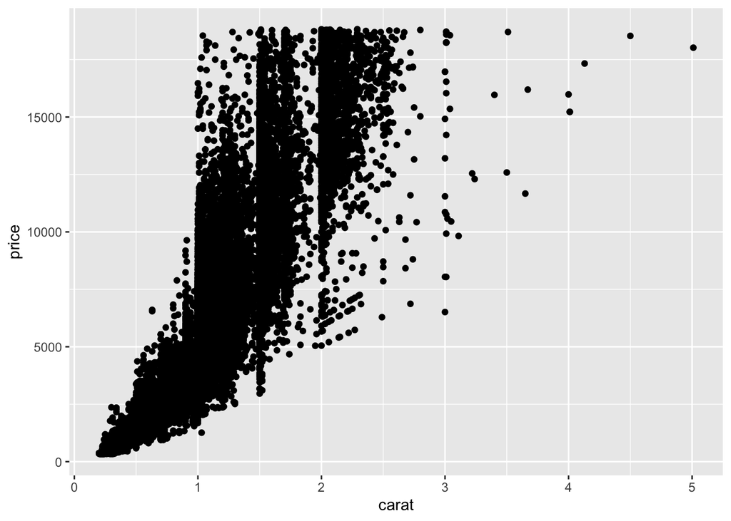

```r
qplot(x = carat, y = price, data = diamonds) # by default if x and y supplied - will plot scatterplot (as geom = "point"), can use geom argument to change plot type.
```

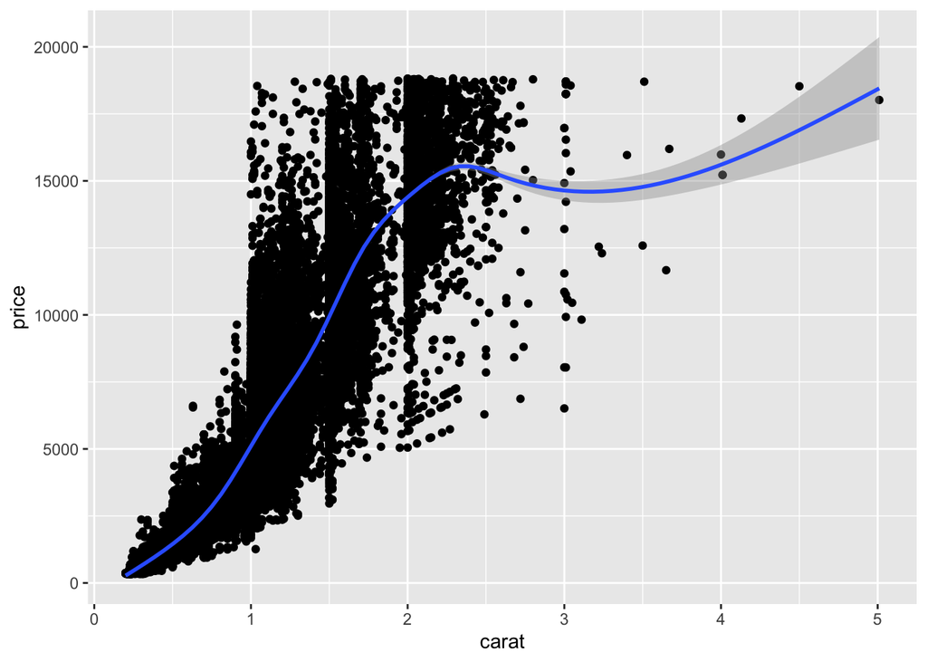

```r
qplot(x = carat, y = price, data = diamonds, geom = c("point","smooth"))
```

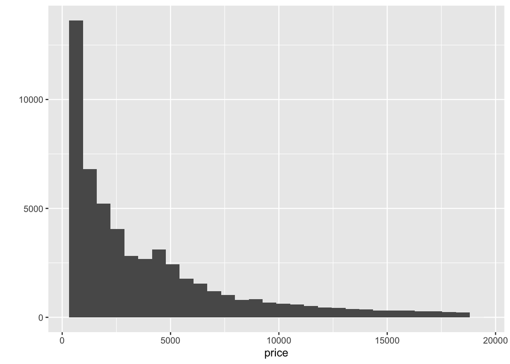

```r
qplot(x = price, data = diamonds)
```

### PRACTICE: Creating spectacular plots

1. Use `ggplot()` to create a more sophisticated graph for the `diamonds` data that shows the relationship between price (price) and carat weight (carat) with coloring by the clarity rating (clarity). Adjust the transparency to better see overlapped points.

**Solution**

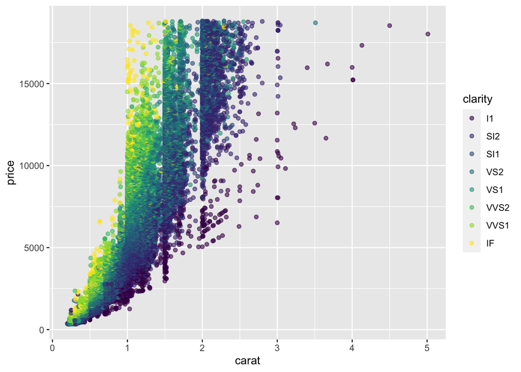

```r
## Both options below work to generate scatterplot of price vs carat weight, colored by clarity rating:

#setting x, y variables locally (i.e., in geom_point):
ggplot(diamonds) +
  geom_point(aes(x = carat, y = price, color = clarity), alpha = 0.6) #alpha adjusts transparency - put outside of aes call to apply to all points
```

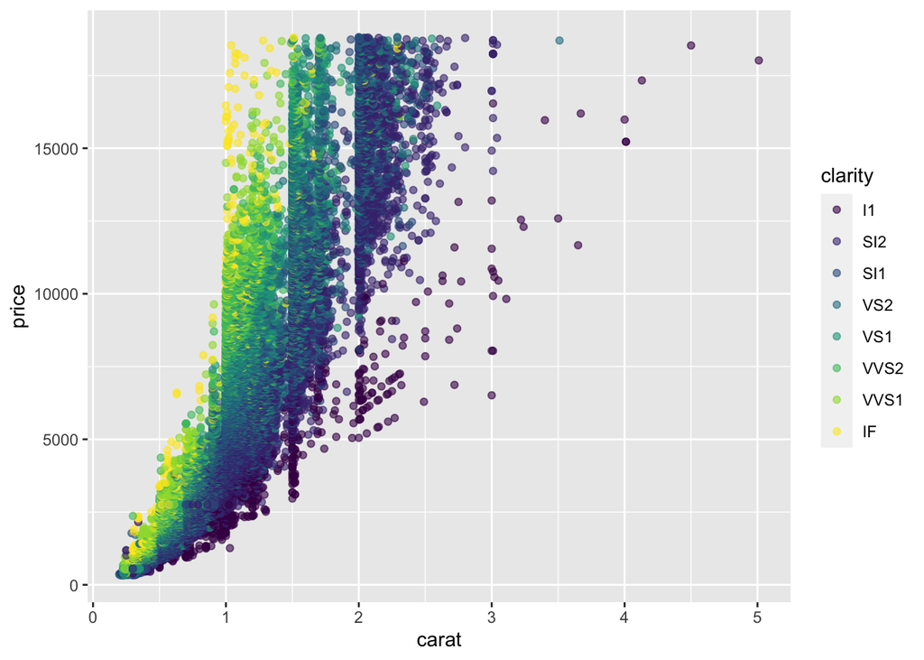

```r
#setting x, y variables globally (i.e., in ggplot function call):
ggplot(diamonds, aes(x = carat, y = price)) +
  geom_point(aes(color = clarity), alpha = 0.6)
```

### PRACTICE: Faceting plots

As we learned, `ggplot2` has several faceting functions to divide plots into subplots based on categorical variable values.

1. Modify the plot above: instead of coloring points by the clarity rating, create individual plots for each group using faceting. Experiment with faceting into rows, columns, or a rectangular layout to see the difference and determine which may be best for this visualization.
2. Select your favorite version of the faceted plot and modify the scales to be “free”. What effect does this have on your plot?

**Solution**

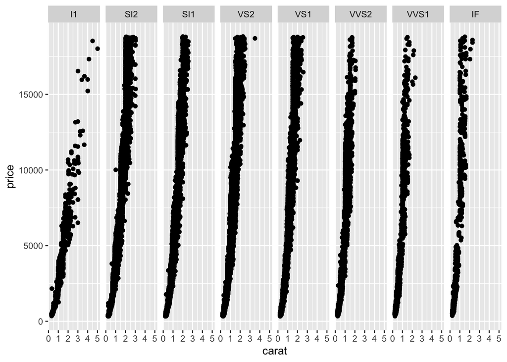

```r
# Facet into columns with a single row
ggplot(diamonds, aes(x = carat, y = price)) +
  geom_point() +
  facet_grid(~clarity)
```

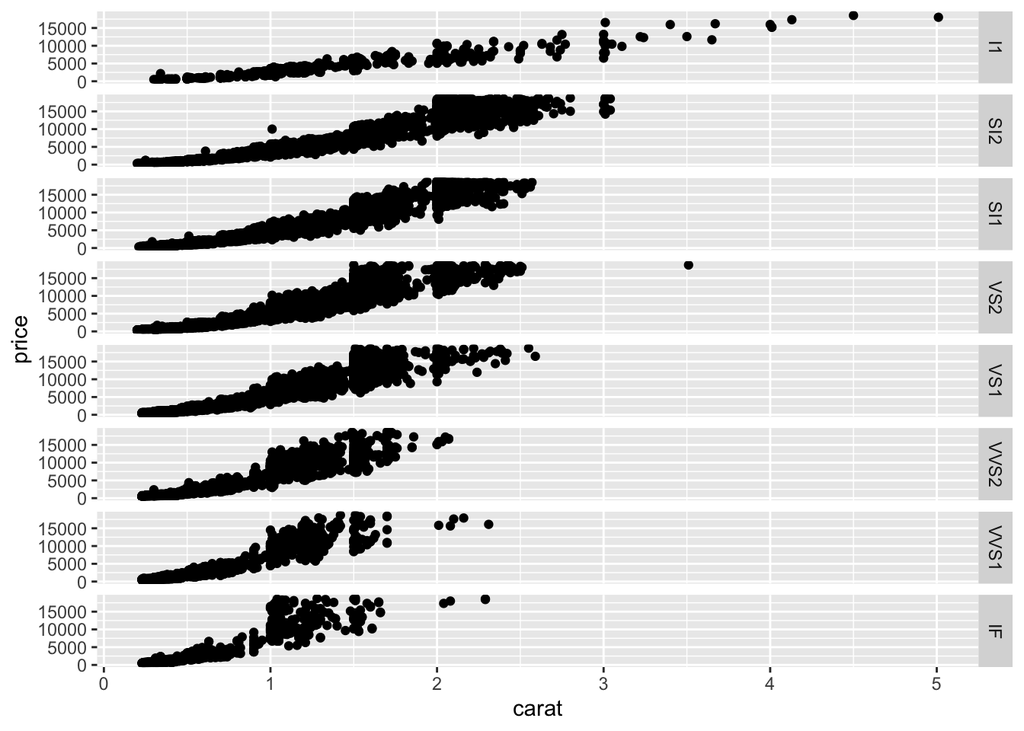

```r
# Facet into rows with a single column
ggplot(diamonds, aes(x = carat, y = price)) +
  geom_point() +
  facet_grid(clarity~.)
```

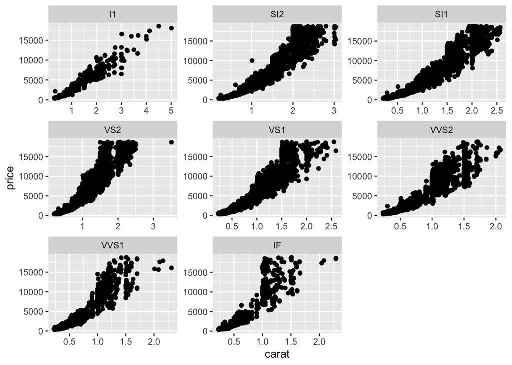

```r
# Facet into rectangular layout (rows and columns)
ggplot(diamonds, aes(x = carat, y = price)) +
  geom_point() +
  facet_wrap(~clarity, scales = "free")
```